# Project 2

Akshay_Gupta_36-600_Project_2

### Load necessary libraries

```r
suppressPackageStartupMessages(library(tidyverse))  # For data manipulation
suppressPackageStartupMessages(library(corrplot))   # For correlation plots
suppressPackageStartupMessages(library(car))        # For variance inflation factor (VIF) analysis
suppressPackageStartupMessages(library(leaps))      # For best subset selection
suppressPackageStartupMessages(library(glmnet))     # For Ridge and LASSO models
suppressPackageStartupMessages(library(caret))      # For data partitioning and cross-validation
```

### Load and Inspect the Data stellar_temperature.csv

```r
star_data <- read.csv("stellar_temperature.csv")

str(star_data)
```

```
## 'data.frame':    10000 obs. of  12 variables:
##  $ teff    : num  6112 5173 6122 6266 6717 ...
##  $ ra_x    : num  239.7 39.8 143.6 118.6 291.6 ...
##  $ dec_x   : num  23.18 36.76 9.22 16.17 39.22 ...
##  $ parallax: num  1.304 3.606 1.163 0.979 1.646 ...
##  $ pmra    : num  -7.268 25.877 10.092 -0.166 5.901 ...
##  $ pmdec   : num  2.029 -172.907 -10.563 -9.018 0.276 ...
##  $ g_mag   : num  13.7 13.1 13.8 12.9 11.3 ...
##  $ b_mag   : num  14 13.6 14.1 13.1 11.6 ...
##  $ r_mag   : num  13.2 12.5 13.4 12.5 11 ...
##  $ br_col  : num  0.319 0.463 0.277 0.267 0.219 ...
##  $ L       : num  38.4 145.8 224.4 205 71.8 ...
##  $ B       : num  47.6 -21.3 40.3 21 10.6 ...
```

```r
summary(star_data)
```

```
##       teff           ra_x              dec_x            parallax
##  Min.   :3664   Min.   :  0.0043   Min.   :-85.713   Min.   : 0.1179
##  1st Qu.:4911   1st Qu.: 80.6802   1st Qu.:  9.583   1st Qu.: 0.6239
##  Median :5548   Median :131.7663   Median : 25.928   Median : 1.0460
##  Mean   :5518   Mean   :154.5872   Mean   : 23.149   Mean   : 1.4354
##  3rd Qu.:6018   3rd Qu.:231.4918   3rd Qu.: 39.772   3rd Qu.: 1.7423
##  Max.   :8631   Max.   :359.9147   Max.   : 85.299   Max.   :16.9419
##       pmra               pmdec               g_mag            b_mag
##  Min.   :-258.5010   Min.   :-207.1520   Min.   : 5.191   Min.   : 5.776
##  1st Qu.:  -5.9387   1st Qu.:  -9.3328   1st Qu.:12.777   1st Qu.:13.207
##  Median :  -0.9095   Median :  -4.0930   Median :13.878   Median :14.322
##  Mean   :  -1.6585   Mean   :  -6.0106   Mean   :13.831   Mean   :14.302
##  3rd Qu.:   3.1290   3rd Qu.:  -0.5092   3rd Qu.:14.983   3rd Qu.:15.481
##  Max.   : 188.1720   Max.   : 106.0590   Max.   :18.809   Max.   :19.448
##      r_mag            br_col               L                  B
##  Min.   : 4.564   Min.   :-0.08625   Min.   :  0.0385   Min.   :-89.23
##  1st Qu.:12.204   1st Qu.: 0.33404   1st Qu.: 91.5764   1st Qu.:-16.91
##  Median :13.287   Median : 0.42862   Median :163.1523   Median : 12.25
##  Mean   :13.222   Mean   : 0.47147   Mean   :154.3933   Mean   : 11.80
##  3rd Qu.:14.362   3rd Qu.: 0.57561   3rd Qu.:198.4155   3rd Qu.: 37.98
##  Max.   :18.689   Max.   : 2.27454   Max.   :359.9994   Max.   : 89.42
```

```r
colSums(is.na(star_data)) # no 'na' values
```

```
##     teff     ra_x    dec_x parallax     pmra    pmdec    g_mag    b_mag
##        0        0        0        0        0        0        0        0
##    r_mag   br_col        L        B
##        0        0        0        0
```

### Exploratory Data Analysis (EDA)

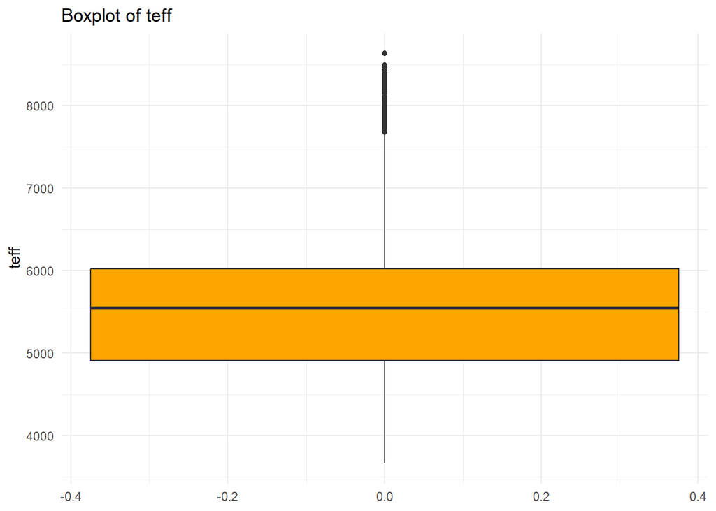

```r
# Visualize outliers in the target variable using a boxplot
ggplot(star_data, aes(y = teff)) +
  geom_boxplot(fill = "orange") +
  labs(title = "Boxplot of teff") +
  theme_minimal()
```

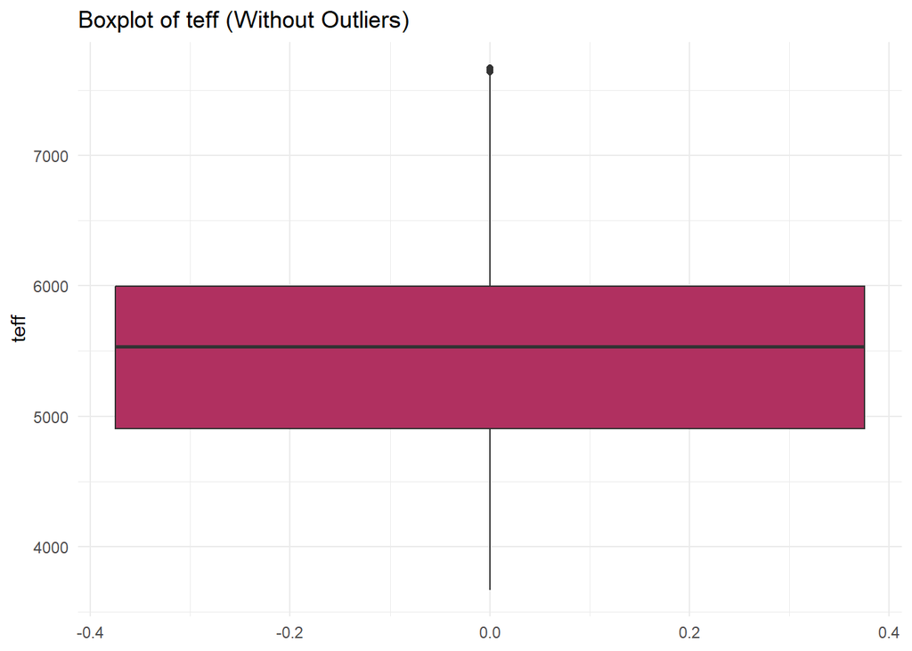

```r
# Calculate Q1 (25th percentile) and Q3 (75th percentile)
Q1 <- quantile(star_data$teff, 0.25)
Q3 <- quantile(star_data$teff, 0.75)

# Calculate the IQR
IQR_value <- IQR(star_data$teff)

# Define bounds for identifying outliers
lower_bound <- Q1 - 1.5 * IQR_value
upper_bound <- Q3 + 1.5 * IQR_value

# Create a new dataset without outliers
star_data_no_outliers <- star_data[star_data$teff >= lower_bound & star_data$teff <= upper_bound, ]

# Visualize the boxplot of teff without outliers
ggplot(star_data_no_outliers, aes(y = teff)) +
  geom_boxplot(fill = "maroon") +
  labs(title = "Boxplot of teff (Without Outliers)") +
  theme_minimal()
```

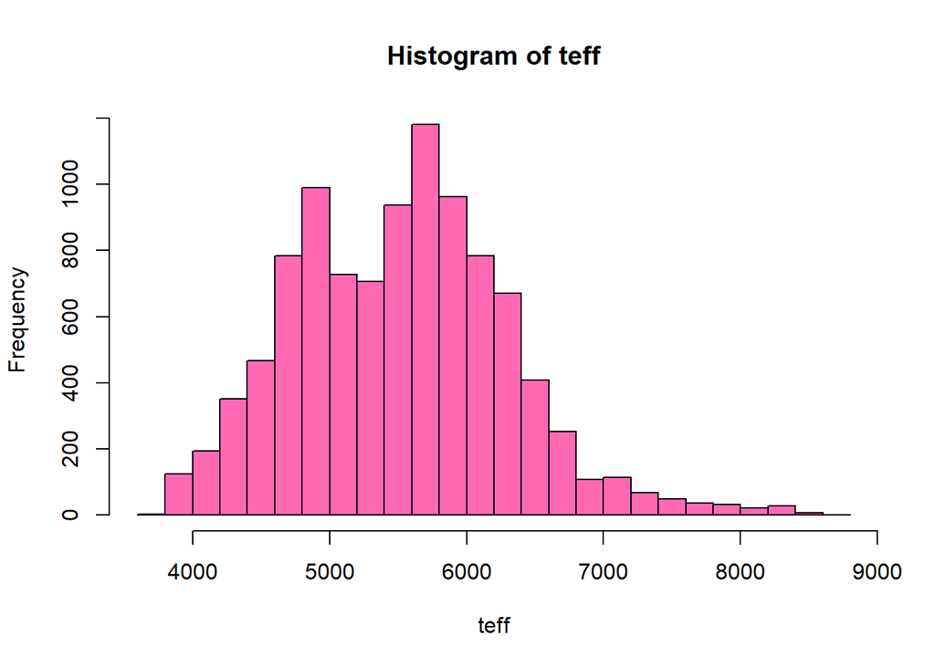

```r
# Histogram for teff
hist(star_data$teff, main = "Histogram of teff", xlab = "teff", breaks = 20, col = "hotpink", border = "black")
```

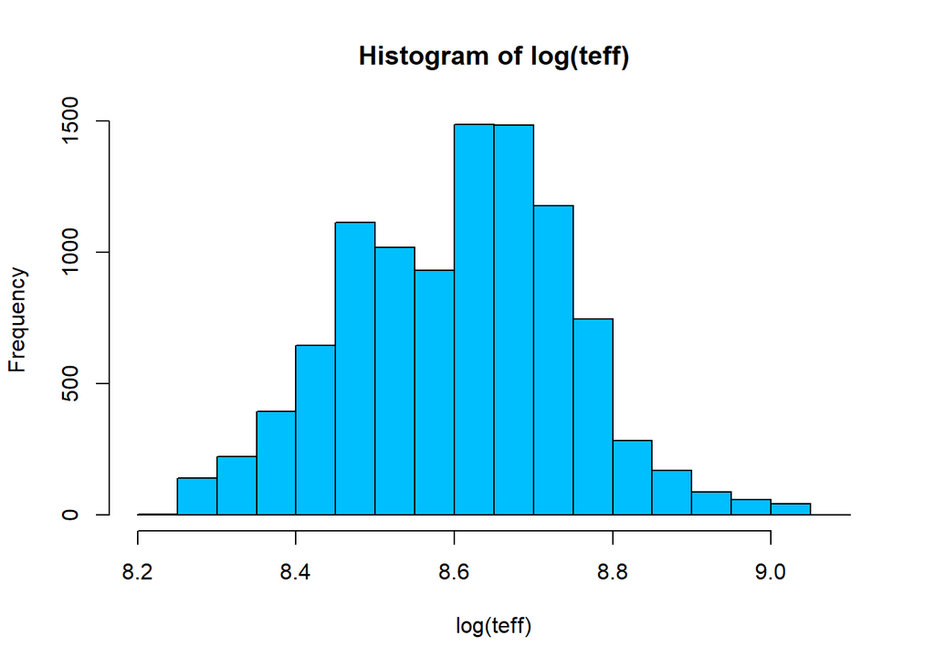

```r
# Apply a log transformation to teff for normalization
log_teff <- log(star_data$teff)

# Histogram for log(teff)
hist(log_teff, main = "Histogram of log(teff)", xlab = "log(teff)", breaks = 20, col = "deepskyblue", border = "black")
```

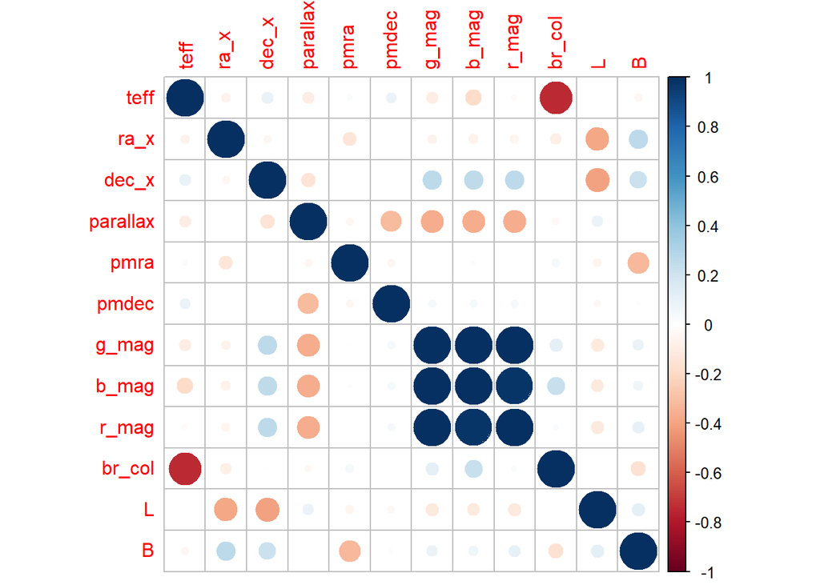

```r
# Generate a correlation plot to visualize relationships between variables
cor_matrix <- cor(star_data) # Calculate correlation matrix
corrplot(cor_matrix, method = "circle") # Display correlation plot
```

The distribution of the target variable, teff is not normal and is right skewed. I applied a log transform on teff to normalize as shown in the plots. But we will use the default data to train our models as the log transformed data is still not normally distributed. I removed some outliers to try and make the data more normally distributed. For the correlation plot, strong positive correlations are indicated by dark blue circles such as those involving variables g_mag, b_mag, and r_mag. This suggests these variables are collinear. Negative correlations are indicated by dark red circles, such as those involving br_col and teff, indicate strong negative correlations, which could also contribute to multicollinearity if these variables are used together in a model.

### Splitting the Data

```r
# Set a random seed for reproducibility of results
set.seed(123)

# Create a random sample of row indices for the training set
# The sample size is 70% of the total number of rows in  star_data
train_index <- sample(seq_len(nrow(star_data)), size = 0.7 * nrow(star_data))

# Create the training data set using the sampled indices
train_data <- star_data[train_index, ]

# Create the test data set by excluding the training indices from the star_data (30%)
test_data <- star_data[-train_index, ]

# Print the size of the training set
cat("Training set size:", nrow(train_data), "\n")
```

```
## Training set size: 7000
```

```r
# Print the size of the test set
cat("Test set size:", nrow(test_data), "\n")
```

```
## Test set size: 3000
```

I did a 70%-30% split for the training and test data since the dataset size is large (10000 rows)

### Analysis with Linear Regression

```r
# Fit linear regression model using teff as the response variable
lm_model <- lm(teff ~ . - teff, data = train_data)  # Exclude teff from predictors

# Display model summary
summary(lm_model)
```

```
##
## Call:
## lm(formula = teff ~ . - teff, data = train_data)
##
## Residuals:
##     Min      1Q  Median      3Q     Max
## -1116.2  -279.0   -84.7   148.8  4341.7
##
## Coefficients: (1 not defined because of singularities)
##               Estimate Std. Error t value Pr(>|t|)
## (Intercept)  8.260e+03  6.870e+01 120.238  < 2e-16 ***
## ra_x        -4.239e-01  7.005e-02  -6.051 1.51e-09 ***
## dec_x        5.230e+00  2.995e-01  17.461  < 2e-16 ***
## parallax    -6.845e+01  4.656e+00 -14.704  < 2e-16 ***
## pmra         2.259e-01  3.988e-01   0.566    0.571
## pmdec        1.780e+00  4.464e-01   3.987 6.75e-05 ***
## g_mag       -6.598e+03  4.196e+02 -15.723  < 2e-16 ***
## b_mag        1.153e+03  1.902e+02   6.060 1.43e-09 ***
## r_mag        5.447e+03  2.322e+02  23.458  < 2e-16 ***
## br_col              NA         NA      NA       NA
## L            6.844e-01  9.839e-02   6.956 3.82e-12 ***
## B           -4.324e+00  1.905e-01 -22.702  < 2e-16 ***
## ---
## Signif. codes:  0 '***' 0.001 '**' 0.01 '*' 0.05 '.' 0.1 ' ' 1
##
## Residual standard error: 458.9 on 6989 degrees of freedom
## Multiple R-squared:  0.6554, Adjusted R-squared:  0.6549
## F-statistic:  1329 on 10 and 6989 DF,  p-value: < 2.2e-16
```

```r
# Generate predictions for both training and test sets
train_preds <- predict(lm_model, newdata = train_data)  # Predictions on training data
test_preds <- predict(lm_model, newdata = test_data)    # Predictions on test data

# Calculate MSE and RMSE for the test set using original teff
mse <- mean((test_data$teff - test_preds)^2)  # Mean Squared Error
rmse <- sqrt(mse)  # Root Mean Squared Error

# Print MSE and RMSE values
print(paste("MSE for the test set:", mse))
```

```
## [1] "MSE for the test set: 196969.138921987"
```

```r
print(paste("RMSE for the test set:", rmse))
```

```
## [1] "RMSE for the test set: 443.812053601507"
```

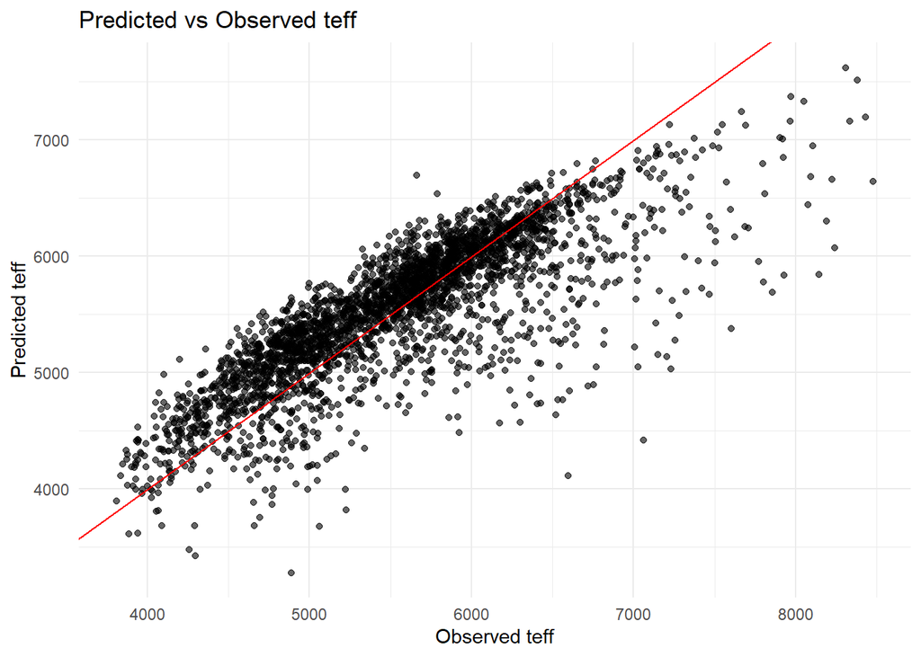

```r
# Create a data frame for ggplot
prediction_data <- data.frame(
  Observed = test_data$teff,
  Predicted = test_preds
)

# Plot Predicted vs Observed values using ggplot
ggplot(prediction_data, aes(x = Observed, y = Predicted)) +
  geom_point(alpha = 0.6) +  # Add points with some transparency
  geom_abline(slope = 1, intercept = 0, color = "red", linetype = "solid") +  # Diagonal line for perfect prediction
  labs(title = "Predicted vs Observed teff",
       x = "Observed teff",
       y = "Predicted teff") +
  theme_minimal()
```